```python
path="C:/Users/maria/Documents/Universidad/Visualización Python/"
```

# TALLER 1

#### María Alejandra Bolívar Cárdenas 2228286

### Visualización uno

#### How Does Your State Make Electricity? ¿Cómo produce electricidad su estado?

La primera visualización a analizar es tomada del NYTimes acerca de las fuentes de generación de electricidad en los Estados Unidos, en contexto el gas natural ha superado al carbón como la principal fuente de generación del país por lo cual se queria saber el porcentaje de energía producida por cada una de estas, ya que las energías renovables han logrado pequeñas pero rápidas ganancias.

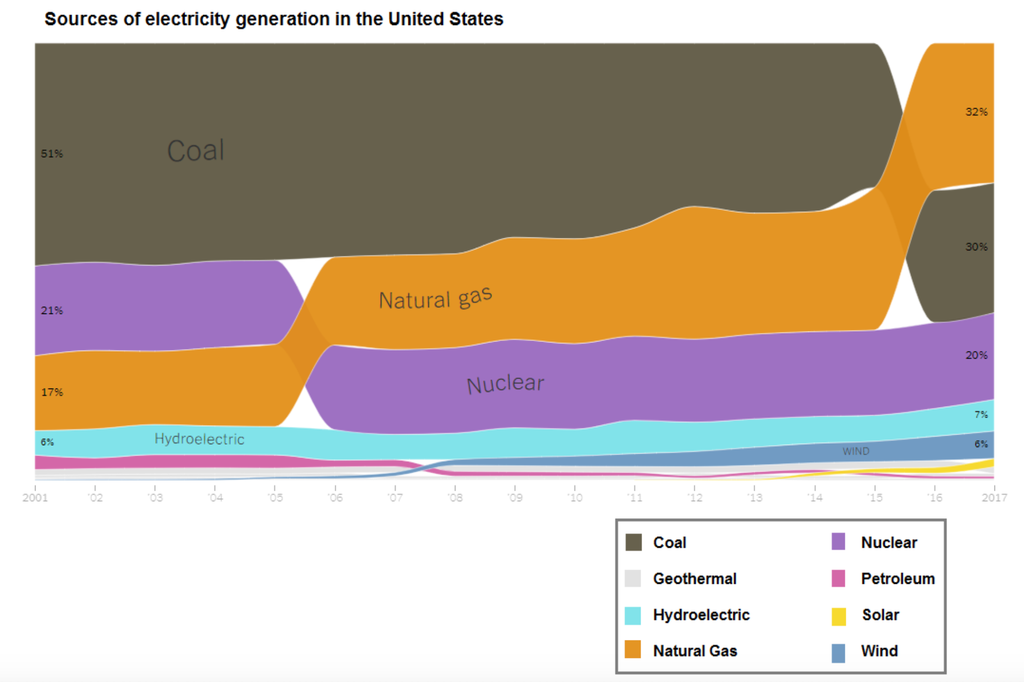

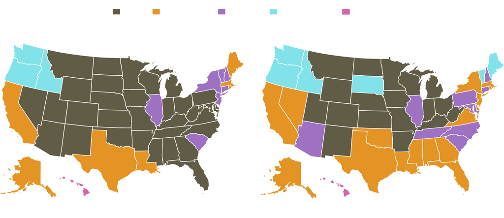

https://www.nytimes.com/2020/06/10/learning/over-60-new-york-times-graphs-for-students-to-analyze.html

Está visualización nos muestra el porcentaje de energía producida a partir de cada fuente de energía de 2001 a 2017

##### *¿Qué?, ¿Porqué? y ¿Cómo?*

1. ¿Qué?

1. ¿Porque?

• Con esta visualización se quiere mirar el comportamiento y la proporción de las fuentes de energía a nivel geográfico, se descubre y analiza en que estados se concentra cierto tipo de combustible, se lleva un registro de los datos a través de cierto tiempo y se identifica su porcentaje.

• En la visualización se identifican características y tendencias hacia cierto tipo de combustibles, es decir, que se ve más que otros. Se ven proporciones comparables y otras similares, además, de que esta definida por forma(área).

1. ¿Cómo?

• Como podemos observar la visualización cuenta con una interacción sencilla ya que solo bajando el cursor se pueden ver los cambios que han tenido las fuentes de energía, además, de que va dando una pequeña explicación sobre que combustible se ve más en cada estado.

• Los pasos de esta visualización fueron Codificar -> Analizar -> Filtrar -> Yuxtaponer.

##### *Marcas y Canales*

1. Marcas

•Marca de área geografica.

1. Canal

•Canal de posición espacial horizontal para el atributo de tiempo y canal de posición espacial vertical para el atributo porcentajes.

•Canal de color para cada atributo categórico el cual nos permite distinguir de un area geográfica a otra que fuente de electricidad es más fuerte.

•Canal de volumen.

##### *Cumple o no cumple alguna de las reglas generales descritas*

• Cumple con las las reglas generales, pues utiliza la interacción y el movimiento de la imagen. Aunque, la forma en que utilizaron el gráfico no es tan atractiva visualmente explica bien y se ve detallado la proporción que cada una de las fuentes tiene en cada uno de los estados. En la siguiente Imagen a la del movimiento se puede ver más detalladamente como se comparan las fuentes por zonas geográficas.

##### *Mejoras posibles, en cuánto a marcas o canales, que le realizaría a la visualización**

• En mi opinión la visualización es buena, aunque le cambiaria un poco la forma en que esta echa puesto que los tamaños o las proporciones no son muy agradables a la vista. La visualización esta un poco cargada en la gama de colores hay unas fuentes de energía que se pierden.

##### *Fuente*

https://www.nytimes.com/2020/06/10/learning/over-60-new-york-times-graphs-for-students-to-analyze.html

### Visualización dos

#### Analyzing plot trends for every top-grossing film from the past 50 years (Analizar las tendencias de la trama de todas las películas más taquilleras de los últimos 50 años.)

La segunda visualización a analizar es tomada de The Pudding acerca de las tendencias argumentales de todas las películas más taquilleras de los últimos 50 años donde se hace una cronología de las 200 películas más taquilleras de cada año entre 1966 y 2016.

[figure not shown]

Para ver un poco mejor la visualización

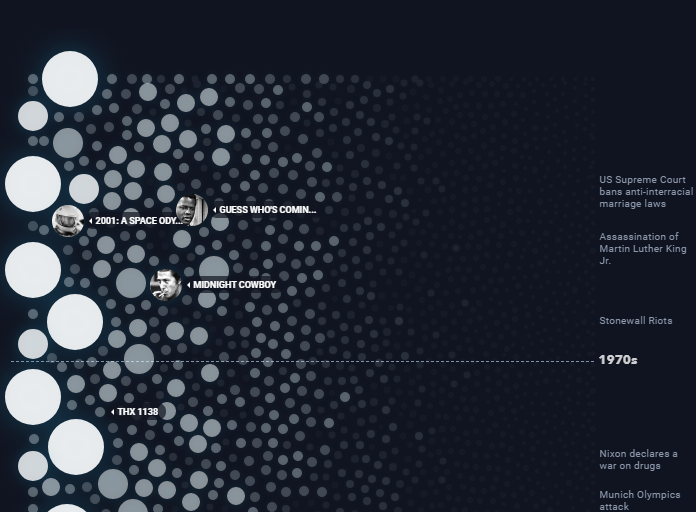

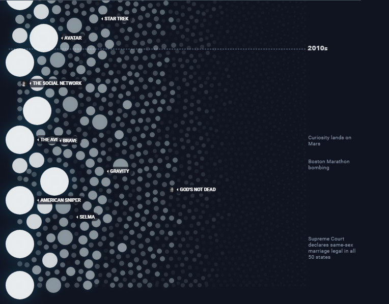

https://pudding.cool/2017/06/film-trends/

Está visualización nos muestra la cronología de las 200 películas más taquilleras de 1966 a 2016.

##### *¿Qué?, ¿Porqué? y ¿Cómo?*

1. ¿Qué?

• Los datos lo que quieren mostrar es la cronología y la dimensión por taquilla es decir el beneficio bruto de esa película en cada año, además la popularidad y el recibimiento de cada película entre 1966 y 2016, con esto se sabe que los datos son numéricos ya que se está midiendo por el número de entradas, se utilizan también atributos y posiciones.

1. ¿Porqué?

• Con esta visualización se quiere mirar el comportamiento, la cronología y la dimensión por taquilla, se analiza el gasto que tienen las personas con respecto a las películas más taquilleras, se manifiesta, se registra y identifica cuáles son las películas más vendidas y más vistas por las personas

• En la visualización se identifican características y tendencias hacia cierto tipo de películas, es decir, que se películas ven más personas atreves del tiempo. Se ven proporciones y características comparables, además, de que está definida por topología y nodos.

1. ¿Cómo?

• Como podemos observar la visualización cuenta con una animación inmersa es decir una interacción dinámica y diferente ya que le permite al usuario interactuar y entrar más allá en la visualización, el usuario se puede ubicar en cada puntico, ver el nombre de la película, el beneficio bruto y el tema del que trata la película.

• Los pasos de esta visualización fueron Codificar -> Navegar -> Analizar -> Filtrar -> Selccionar.

##### *Marcas y Canales*

1. Marcas

• Marca de puntos con posición vertical a través del tiempo con volumen

1. Canales

• Canal de posición espacial horizontal para el atributo películas y canal de posición espacial vertical para el atributo de tiempo

• Canal de volumen para atributo (Películas) donde las más vistas son las más grandes y las más pequeñas las menos vistas

• Canal de color en escala de grises

##### *Cumple o no cumple alguna de las reglas generales descritas*

• Cumple con las las reglas generales, pues utiliza la interacción y movimiento en imagen. No utiliza innecesariamente recursos, adicional a que utiliza la navegación y la interacción dentro de una sola vista para poder comparar, distinguir y analizar cada tipo de película, además se puede detallar en cada circulo el nombre, el genero o tema del que trate y su beneficio bruto.

La discriminación visual está bien echa pues se al pararse en el punto de la imagen se puede ver el nombre y las características de esta película, cada puntico es independiente del otro lo cual lo hace más fácil de entender. Utiliza el canal vertical como prioridad, lo cual hace que cumple con la mayoría de reglas.

##### *Mejoras posibles, en cuánto a marcas o canales, que le realizaría a la visualización**

• En mi opinión la visualización es muy buena, aunque le cambiaria un poco el color, es decir, que el fondo sea un poco más claro o tenga más gama de colores para identificar mejor los puntos pues ya muy a la parte derecha los puntos se pierden con el color del fondo del programa.

##### *Fuente*

https://pudding.cool/2017/06/film-trends/